# (Airline on time Dataset Exploration)

## Preliminary Wrangling

> This dataset reports flights in the United States, including carriers, arrival and departure delays, and reasons for delays, from 1987 to 2008. The data comes originally from RITA where it is described in detail. During this exploration we will be looking at year 2008 to answer questions like:

> 1) Are there certain destination or arrival cities that are home to more delays or cancellations?

> 2) What are the preferred times for flights to occur?

> 3) Are there certain flight distances home to more delays or cancellations?

```python
# import all packages and set plots to be embedded inline
import numpy as np
import pandas as pd
import matplotlib.pyplot as plt
import seaborn as sb

%matplotlib inline
```

> First we load the 2008 dataset

```python
df = pd.read_csv('2008.csv')
df.head()
```

|  | Year | Month | DayofMonth | DayOfWeek | DepTime | CRSDepTime | ArrTime | CRSArrTime | UniqueCarrier | FlightNum | ... | TaxiIn | TaxiOut | Cancelled | CancellationCode | Diverted | CarrierDelay | WeatherDelay | NASDelay | SecurityDelay | LateAircraftDelay |
| --- | --- | --- | --- | --- | --- | --- | --- | --- | --- | --- | --- | --- | --- | --- | --- | --- | --- | --- | --- | --- | --- |
| 0 | 2008 | 1 | 3 | 4 | 1343.0 | 1325 | 1451.0 | 1435 | WN | 588 | ... | 4.0 | 9.0 | 0 | NaN | 0 | 16.0 | 0.0 | 0.0 | 0.0 | 0.0 |
| 1 | 2008 | 1 | 3 | 4 | 1125.0 | 1120 | 1247.0 | 1245 | WN | 1343 | ... | 3.0 | 8.0 | 0 | NaN | 0 | NaN | NaN | NaN | NaN | NaN |
| 2 | 2008 | 1 | 3 | 4 | 2009.0 | 2015 | 2136.0 | 2140 | WN | 3841 | ... | 2.0 | 14.0 | 0 | NaN | 0 | NaN | NaN | NaN | NaN | NaN |
| 3 | 2008 | 1 | 3 | 4 | 903.0 | 855 | 1203.0 | 1205 | WN | 3 | ... | 5.0 | 7.0 | 0 | NaN | 0 | NaN | NaN | NaN | NaN | NaN |
| 4 | 2008 | 1 | 3 | 4 | 1423.0 | 1400 | 1726.0 | 1710 | WN | 25 | ... | 6.0 | 10.0 | 0 | NaN | 0 | 16.0 | 0.0 | 0.0 | 0.0 | 0.0 |

5 rows × 29 columns

> Then we load the airports dataset.It is needed to get the city and state names for the origin and destation of the flight.

```python
df_airports = pd.read_csv('airports.csv')
df_airports.head()
```

|  | iata | airport | city | state | country | lat | long |
| --- | --- | --- | --- | --- | --- | --- | --- |
| 0 | 00M | Thigpen | Bay Springs | MS | USA | 31.953765 | -89.234505 |
| 1 | 00R | Livingston Municipal | Livingston | TX | USA | 30.685861 | -95.017928 |
| 2 | 00V | Meadow Lake | Colorado Springs | CO | USA | 38.945749 | -104.569893 |
| 3 | 01G | Perry-Warsaw | Perry | NY | USA | 42.741347 | -78.052081 |
| 4 | 01J | Hilliard Airpark | Hilliard | FL | USA | 30.688012 | -81.905944 |

> Create a dictionary to map the IATA with the city name then update the values of origin and destination in the data frame with names instead of codes using the created dictionary.

```python
#create a pandas series using the 2 columns and convert it to dictionary
code_city = pd.Series(df_airports.city.values,index=df_airports.iata).to_dict()
```

```python
#change source and distantion with city names
df['Origin'] = df['Origin'].replace(code_city)
df['Dest'] = df['Dest'].replace(code_city)
```

```python
#check for months and week days in the dataset
df['Month'].unique()
```

```
array([1, 2, 3, 4], dtype=int64)
```

```python
df['DayOfWeek'].unique()
```

```
array([4, 5, 6, 7, 1, 2, 3], dtype=int64)
```

```python
#map with name of months and days  instead of their numbers
dict_month = {1:'January',2:'February',3:'March',4:'April'}
dict_day = {1:'Monday',2:'Tuesday',3:'Wednesday',4:'Thursday',5:'Friday',6:'Saturday',7:'Sunday'}
```

```python
df['Month'] = df['Month'].replace(dict_month)
df['DayOfWeek'] = df['DayOfWeek'].replace(dict_day)
```

```python
df.shape
```

```
(2389217, 29)
```

```python
df.columns
```

```
Index(['Year', 'Month', 'DayofMonth', 'DayOfWeek', 'DepTime', 'CRSDepTime',
       'ArrTime', 'CRSArrTime', 'UniqueCarrier', 'FlightNum', 'TailNum',
       'ActualElapsedTime', 'CRSElapsedTime', 'AirTime', 'ArrDelay',
       'DepDelay', 'Origin', 'Dest', 'Distance', 'TaxiIn', 'TaxiOut',
       'Cancelled', 'CancellationCode', 'Diverted', 'CarrierDelay',
       'WeatherDelay', 'NASDelay', 'SecurityDelay', 'LateAircraftDelay'],
      dtype='object')
```

```python
#check for duplicates
df.duplicated().value_counts()
```

```
False    2389213
True           4
dtype: int64
```

```python
df.drop_duplicates(inplace = True)
df.duplicated().value_counts()
```

```
False    2389213
dtype: int64
```

```python
#check data types
df.info()
```

```
<class 'pandas.core.frame.DataFrame'>
Int64Index: 2389213 entries, 0 to 2389216
Data columns (total 29 columns):
 #   Column             Dtype
---  ------             -----
 0   Year               int64
 1   Month              object
 2   DayofMonth         int64
 3   DayOfWeek          object
 4   DepTime            float64
 5   CRSDepTime         int64
 6   ArrTime            float64
 7   CRSArrTime         int64
 8   UniqueCarrier      object
 9   FlightNum          int64
```

[output cut: 21 more lines]

```python
#check null values for each column in the data set
df.isnull().sum()
```

```
Year                       0
Month                      0
DayofMonth                 0
DayOfWeek                  0
DepTime                64442
CRSDepTime                 0
ArrTime                70096
CRSArrTime                 0
UniqueCarrier              0
FlightNum                  0
TailNum                42452
ActualElapsedTime      70096
CRSElapsedTime           407
AirTime                70096
ArrDelay               70096
DepDelay               64442
Origin                  1691
Dest                    1691
Distance                   0
TaxiIn                 70096
TaxiOut                64442
Cancelled                  0
CancellationCode     2324771
Diverted                   0
CarrierDelay         1804632
WeatherDelay         1804632
NASDelay             1804632
SecurityDelay        1804632
LateAircraftDelay    1804632
dtype: int64
```

```python
#create a df with the columns we are intersted in studying
df = df[['Month','DayOfWeek','ArrDelay','DepDelay','Distance','Cancelled','Origin','Dest']].copy()
```

```python
#from the selected columns ArrDelay, DepDelay , origin and dest have null
#so we first will replace the null values in the depdelay and arrdelay with the mean value
df['ArrDelay']=df['ArrDelay'].replace(np.nan,df['ArrDelay'].mean())
df['DepDelay']=df['DepDelay'].replace(np.nan,df['DepDelay'].mean())
```

```python
df.isnull().sum()
```

```
Month           0
DayOfWeek       0
ArrDelay        0
DepDelay        0
Distance        0
Cancelled       0
Origin       1691
Dest         1691
dtype: int64
```

```python
#then we will drop the rows with missing origin and dest values to get rid of all nans in the df
df.dropna(inplace=True)
```

```python
df.isnull().sum()
```

```
Month        0
DayOfWeek    0
ArrDelay     0
DepDelay     0
Distance     0
Cancelled    0
Origin       0
Dest         0
dtype: int64
```

```python
df.shape
```

```
(2385831, 8)
```

### What is the structure of your dataset?

> The original dataset after removing duplicates contains 2389213 entry and 29 features and the modified dataset with the concerned feautres and null values removed contains 2385831 entry and 8 feautres.

### What is/are the main feature(s) of interest in your dataset?

> Main helpful feauters are the feauters related to flights' delay,cancelation,date and destianion of the delayed or cancelled flight.

### What features in the dataset do you think will help support your investigation into your feature(s) of interest?

> Month, DayOfWeek, ArrDelay, DepDelay, Origin, Dest, Cancelled and Distance.

## Univariate Exploration

> Exploring the number of flights during each month

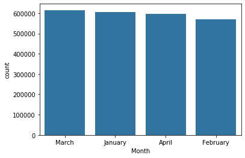

```python
month_counts = df['Month'].value_counts()
month_order = month_counts.index
base_color = sb.color_palette()[0]
sb.countplot(data=df, x='Month', color=base_color,order=month_order);
```

> There are small diffrences between the number of flights during each month with March recording highest flight numbers and February recording the smallest number of flights.

> Next we will the number of flights for each day of the week

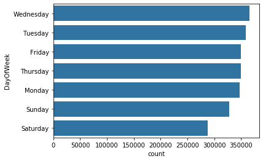

```python
day_counts = df['DayOfWeek'].value_counts()
day_order = day_counts.index
base_color = sb.color_palette()[0]
sb.countplot(data=df, y='DayOfWeek', color=base_color,order=day_order);
```

> From the above plot we see that Saturday recorded lowest number of flights during the year we also noticed a small decrease in flight numbers during weekend VS week days.

> Next we will see the percentage of cancelled flights during the year.

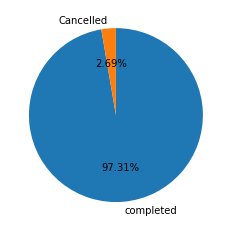

```python
sorted_counts = df.Cancelled.value_counts()
sorted_counts.index = ['completed','Cancelled']
plt.pie(sorted_counts, labels = sorted_counts.index, startangle = 90, counterclock = False, autopct='%.2f%%');
```

> We see that in 2008 only 2.7% of flights were cancelled

> Next we will explore the origin and destination cities

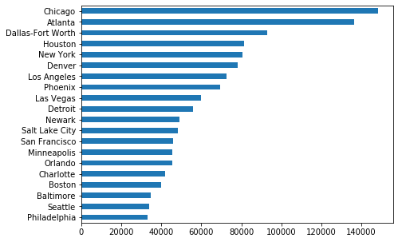

```python
origin_counts = df['Origin'].value_counts()[0:20].sort_values()
origin_counts.plot(x = origin_counts.values , y = origin_counts.index , kind ='barh' ,figsize = (7,5));
```

> we can see that Chigaco was the origin for most flights this year with more than 140000 flights departed from it.

> Next we will explore the distenation cities.

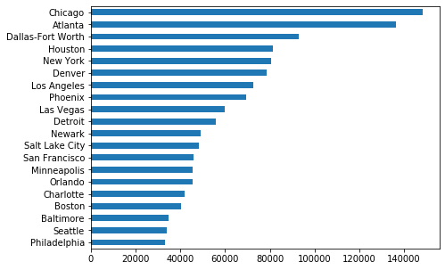

```python
dest_counts = df['Dest'].value_counts()[0:20].sort_values()
dest_counts.plot(x = dest_counts.values , y = dest_counts.index , kind ='barh' ,figsize = (7,5));
```

> From the above plot Chicago is also the most city with flight destination plotting the histogram of the arrival delays in minutes

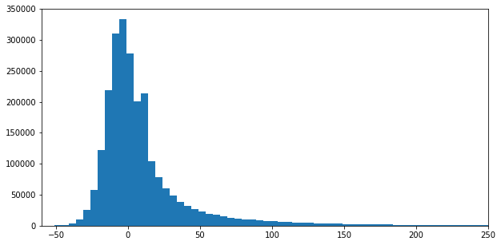

```python
bins = np.arange(df['ArrDelay'].min()-5, df['ArrDelay'].max()+5, 5)
plt.figure(figsize=(10,5))
plt.hist(data = df, x = 'ArrDelay', bins = bins);
plt.xlim(-60,250);
```

```python
df['ArrDelay'].max()
```

```
2461.0
```

> as seen from the above histogram most of the arrival delays ranges from -30 to +30 minutes but there are outliers that reached 2461 minutes nearly a day. we limited the x axis to range from -60 to 250 as the effect of the outlier will make the plot unclear.

> Next we will do the same for the departure delay

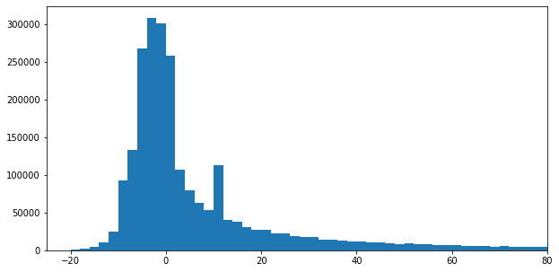

```python
bins = np.arange(df['DepDelay'].min()-2, df['DepDelay'].max()+2, 2)
plt.figure(figsize=(10,5))
plt.hist(data = df, x = 'DepDelay', bins = bins);
plt.xlim(-25,80);
```

```python
 df['DepDelay'].max()
```

```
2467.0
```

> as seen from the above histogram most of the depareture delays ranges from -15 to +20 minutes but there are outliers that reached 2467 minutes nearly a day. we limited the x axis to range from -25 to 80 as the effect of the outlier will make the plot unclear.

> Finally we will explore the distances.

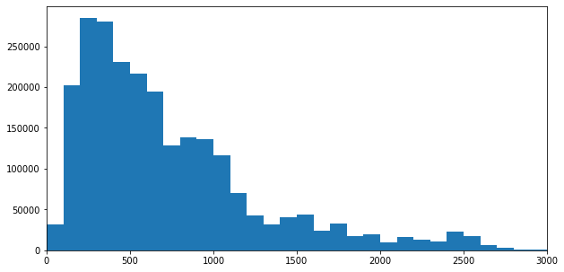

```python
bins = np.arange(0, df['Distance'].max()+100, 100)
plt.figure(figsize=(10,5))
plt.hist(data = df, x = 'Distance', bins = bins);
plt.xlim(0,3000);
```

```python
df['Distance'].max()
```

```
4962
```

> as seen from the above histogram most of the flight distances ranges from 100 to 1000 miles but there are outliers that reached 5000 miles. we limited the x axis to range from 0 to 3000 as the effect of the outlier will make the plot unclear.

## Bivariate Exploration

> At we first we plot the quantitive data scatter plot against each other.

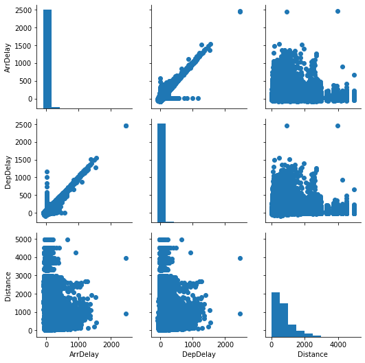

```python
g = sb.PairGrid(data = df, vars = ['ArrDelay', 'DepDelay', 'Distance']);
g.map_diag(plt.hist);
g.map_offdiag(plt.scatter);
```

> as seen from the above plot there is a hight positive corellation between the departure delay and the arrival delay which makes sense. There is no clear relation between the distance, arrival delay, departure delay.

> Next we will explore the relation between the arrival delay, departure delay and day of week, month

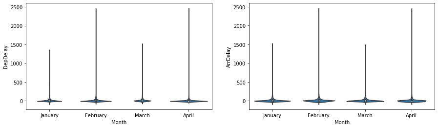

```python
plt.figure(figsize=[15,4])
plt.subplot(1,2,1)
sb.violinplot(data=df, y='DepDelay', x='Month', color=base_color);

plt.subplot(1,2,2)
sb.violinplot(data=df, y='ArrDelay', x='Month', color=base_color);
```

> as seen from the above plots Februray and April encountered more delays than the rest of months due to oultiers

> the below graphs shows more insights

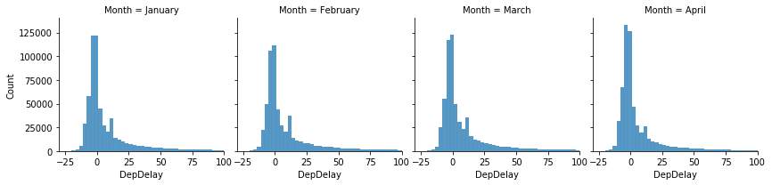

```python
sb.displot(df, x="DepDelay", col="Month",binwidth=3, height=3, facet_kws=dict(margin_titles=True));
plt.xlim(-30,100);
```

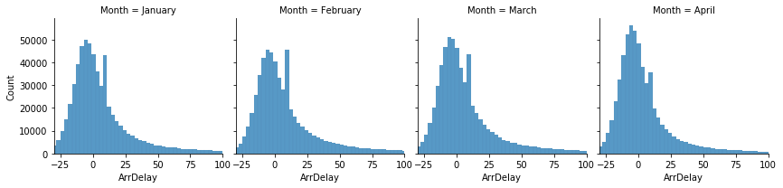

```python
sb.displot(df, x="ArrDelay", col="Month",binwidth=3, height=3, facet_kws=dict(margin_titles=True));
plt.xlim(-30,100);
```

> After viewing the above histograms we can see that in most cases the arrival and departure delay for each month are nearly the same this is only true when neglect the effect of the outliers.

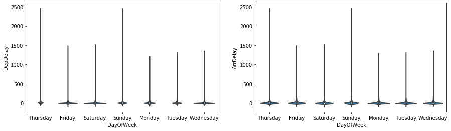

```python
plt.figure(figsize=[15,4])
plt.subplot(1,2,1)
sb.violinplot(data=df, y='DepDelay', x='DayOfWeek', color=base_color);

plt.subplot(1,2,2)
sb.violinplot(data=df, y='ArrDelay', x='DayOfWeek', color=base_color);
```

> Both Thursday and Sunday have more delays than the rest of week days

> Next we will see the histogram for each day on its own.

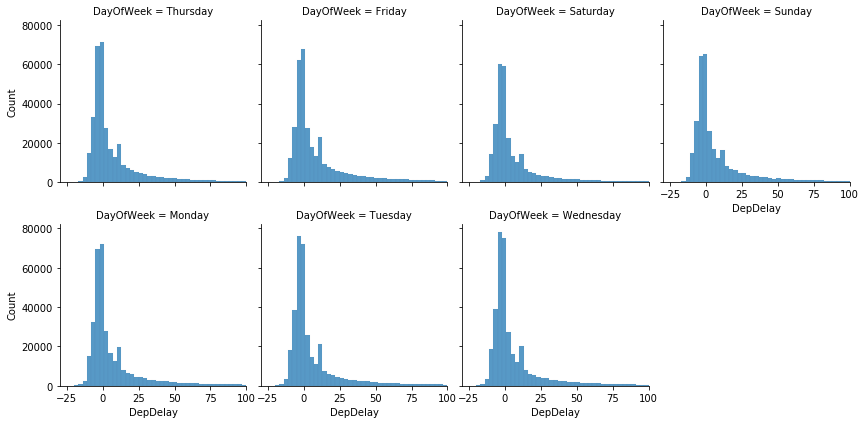

```python
sb.displot(df, x="DepDelay", col="DayOfWeek",binwidth=3, height=3,col_wrap=4, facet_kws=dict(margin_titles=True));
plt.xlim(-30,100);
```

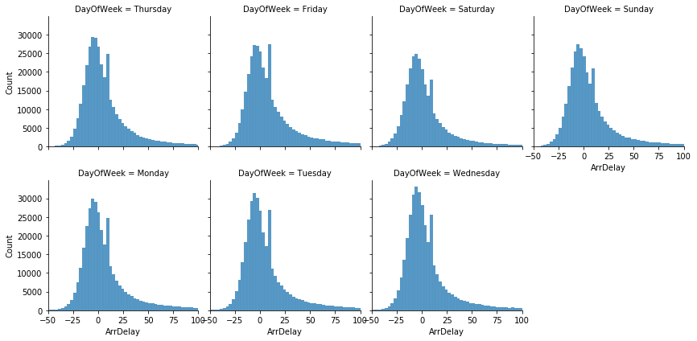

```python
sb.displot(df, x="ArrDelay", col="DayOfWeek",binwidth=3, height=3,col_wrap=4, facet_kws=dict(margin_titles=True));
plt.xlim(-50,100);
```

> After viewing the above histograms we can see that in most cases the arrival and departure delay for each is the same when neglecting the effect of the outliers

> for further investigation next we will plot each month vs only the value of the average arrival and departure delay.

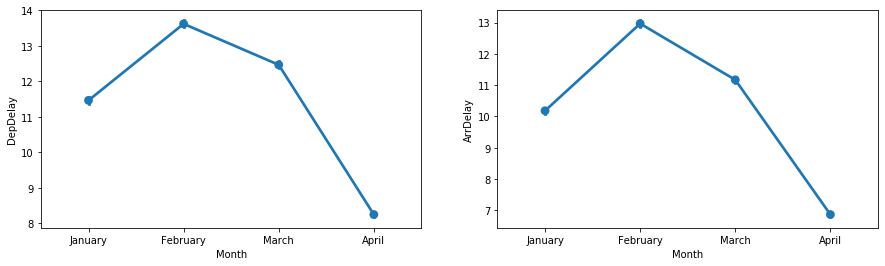

```python
plt.figure(figsize=[15,4])
plt.subplot(1,2,1)
sb.pointplot(data=df, x='Month', y='DepDelay', color=base_color);

plt.subplot(1,2,2)
sb.pointplot(data=df, x='Month', y='ArrDelay', color=base_color);
```

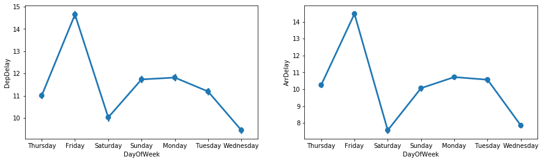

```python
plt.figure(figsize=[15,4])
plt.subplot(1,2,1)
sb.pointplot(data=df, x='DayOfWeek', y='DepDelay', color=base_color);

plt.subplot(1,2,2)
sb.pointplot(data=df, x='DayOfWeek', y='ArrDelay', color=base_color);
```

> Next we will explore the origin and destination cities wiht the most arrival and departure delays

```python
#group the df by origin city then calculate the mean of its arr and dep delay
mean_dep_delay = df.groupby('Origin')['DepDelay'].mean().sort_values(ascending=False)[0:9]
mean_arr_delay = df.groupby('Origin')['ArrDelay'].mean().sort_values(ascending=False)[0:9]
print(mean_dep_delay)
print(mean_arr_delay)
```

```
Origin
Pellston         31.927267
Hancock          26.665060
Crescent City    23.370592
Key West         21.701450
South Bend       21.249613
King Salmon      20.500000
Chicago          20.397486
Mosinee          19.916571
Gunnison         19.752491
Name: DepDelay, dtype: float64
Origin
Pellston            33.560069
Crescent City       24.544707
Hancock             24.459217
Gillette            24.073684
Key West            22.285803
Gunnison            22.067502
Champaign/Urbana    21.601059
Springfield         20.733448
South Bend          20.727193
Name: ArrDelay, dtype: float64
```

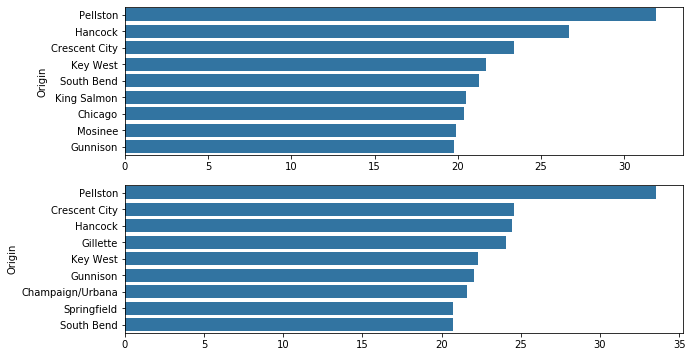

```python
plt.figure(figsize=[10,6])
plt.subplot(2,1,1)
sb.barplot(y=mean_dep_delay.index, x=mean_dep_delay.values, color=base_color);

plt.subplot(2,1,2)
sb.barplot(y=mean_arr_delay.index, x=mean_arr_delay.values, color=base_color);
```

> Next we will do the same for the destination city

```python
mean_dep_delay = df.groupby('Dest')['DepDelay'].mean().sort_values(ascending=False)[0:9]
mean_arr_delay = df.groupby('Dest')['ArrDelay'].mean().sort_values(ascending=False)[0:9]
print(mean_dep_delay)
print(mean_arr_delay)
```

```
Dest
Key West                 24.932833
Champaign/Urbana         24.655161
Mosinee                  23.896642
Newark                   22.808438
Dillingham               20.500000
Wilkes-Barre/Scranton    20.250386
Chicago                  18.941078
Hancock                  18.864459
Harrisburg               18.605795
Name: DepDelay, dtype: float64
Dest
Champaign/Urbana    24.393790
Key West            23.753638
Mosinee             23.613367
Dillingham          20.000000
Newark              19.185842
Chicago             18.917670
Salem               18.528889
Traverse City       18.454352
San Francisco       17.338559
Name: ArrDelay, dtype: float64
```

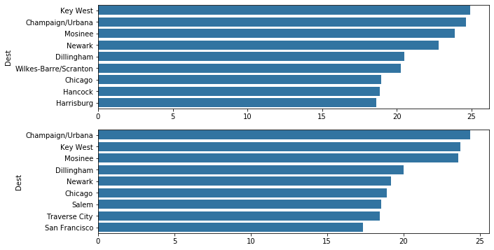

```python
plt.figure(figsize=[10,6])
plt.subplot(2,1,1)
sb.barplot(y=mean_dep_delay.index, x=mean_dep_delay.values, color=base_color);

plt.subplot(2,1,2)
sb.barplot(y=mean_arr_delay.index, x=mean_arr_delay.values, color=base_color);
```

> Now we will explore the months with most cancelled flights

```python
#group by month and caluculate the percentage of cancelled flights for each month
cancelled_month = df.groupby('Month')['Cancelled'].mean().sort_values(ascending=False)
cancelled_month
```

```
Month
February    0.036161
January     0.028497
March       0.026264
April       0.017308
Name: Cancelled, dtype: float64
```

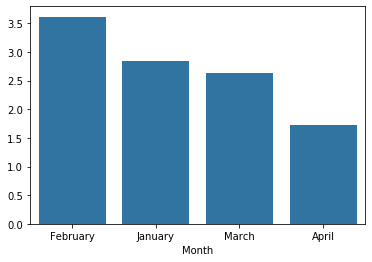

```python
sb.barplot(x=cancelled_month.index, y=cancelled_month.values*100, color=base_color);
```

> Februray had the highest percentage of cancelled flights.

> next we will do the same for week days

```python
day_cancelled = df.groupby('DayOfWeek')['Cancelled'].mean().sort_values(ascending=False)
day_cancelled
```

```
DayOfWeek
Tuesday      0.032953
Friday       0.032938
Wednesday    0.028346
Monday       0.027237
Thursday     0.025244
Saturday     0.021427
Sunday       0.018768
Name: Cancelled, dtype: float64
```

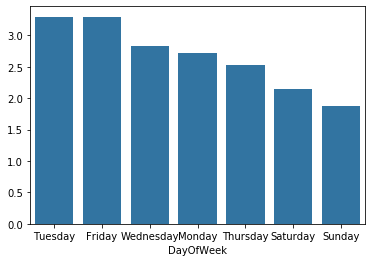

```python
sb.barplot(x=day_cancelled.index, y=day_cancelled.values*100, color=base_color);
```

> Tuesday and Friday have the highest percentage of cancelled flights

> Next we will explore origin and destination citites with the highest percentage of cancelled flights

```python
#group by origin country, calculate the percentage then select the top 11 cities with the highest percentage
origin_cancelled = df.groupby('Origin')['Cancelled'].mean().sort_values(ascending=False)[0:10]
origin_cancelled
```

```
Origin
Pellston       0.315789
Waterloo       0.250000
Telluride      0.210843
Hancock        0.198347
Rhinelander    0.156250
Kalamazoo      0.130790
Hailey         0.129032
Aspen          0.126382
Dubuque        0.119914
Mosinee        0.117308
Name: Cancelled, dtype: float64
```

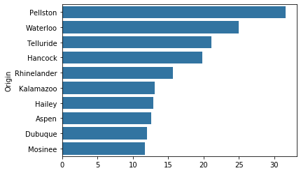

```python
sb.barplot(y=origin_cancelled.index, x=origin_cancelled.values*100, color=base_color);
```

```python
#doing the same for the destination cities
dest_cancelled = df.groupby('Dest')['Cancelled'].mean().sort_values(ascending=False)[0:10]
```

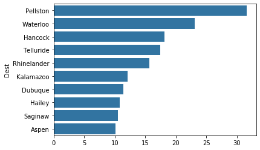

```python
sb.barplot(y=dest_cancelled.index, x=dest_cancelled.values*100, color=base_color);
```

> finally we will see the relation between the distance and cancelling the flight

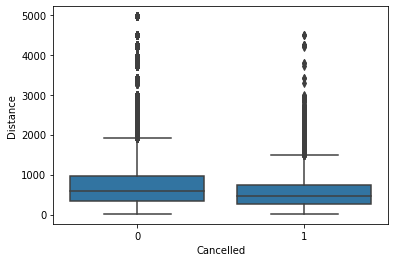

```python
sb.boxplot(data=df, y='Distance', x='Cancelled', color=base_color)
```

> we can see that cancelling flights was more with less distant flights.

## Multivariate Exploration

> At first we will study the effect of distance with the month and arrival delay then with week days

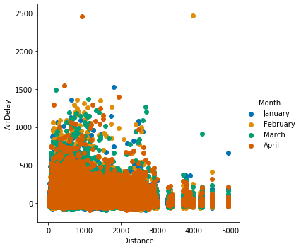

```python
g = sb.FacetGrid(data = df, hue = 'Month', height = 5,palette = 'colorblind');
g.map(plt.scatter, 'Distance', 'ArrDelay');
g.add_legend();
```

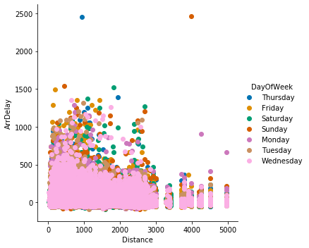

```python
g = sb.FacetGrid(data = df, hue = 'DayOfWeek', height = 5,palette = 'colorblind');
g.map(plt.scatter, 'Distance', 'ArrDelay');
g.add_legend();
```

> The plots are not well informative due to multiple data points stacked on top of each other but we can see that distance of these flights did not affect its delay and the delays are nearly similar for each month and week days expect for some outliers and the effect of these outliers was well presented in the bivariante plots above.

> finally we will explore the effecct of distance with month on the canellation of the flight

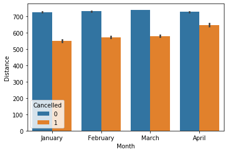

```python
ax = sb.barplot(data = df, x = 'Month', y = 'Distance', hue = 'Cancelled');
```

> from the plot we can see there is no diffrence between month but we can see that cancelling a flight is related with less distant flights.